# New tools for internationally-scalable future-proof transport planning

Robin Lovelace

r.lovelace@leeds.ac.uk

Institute for Transport Studies, University of Leeds

October 22, 2025

## Context

- About me and my background
  - Professor of Transport Data Science at University of Leeds
  - Focus on open, reproducible transport planning tools
  - Worked in Active Travel England to build data and digital capacity
- What I’ll be talking about today: open, reproducible, internationally-scalable transport tools
- How this aligns with GREENTRAVEL project’s aims and themes

## International context

## Why open access beyond open source?

“Open access goes beyond open source … users are encouraged to view and edit the source code, with measures taken to make it more user-friendly.”

Source: (Lovelace, Parkin, and Cohen 2020)

[figure not shown]

## Communities of practice

[figure not shown]

[figure not shown]

- Open source books have 80+ contributors
- Technical solutions are only as good as the community using (and contributing to) them
- Share datasets, reproducible examples
- Pilot features, report bugs, contribute docs

## Example: plan.activetravelengland.gov.uk

[figure not shown]

## Reproducible research in practice

- Fully reproducible pipelines improve trust, reuse and scale
- Example: spanishoddata package and paper now part of rOpenSpain community (Kotov, Lovelace and others, 2025)

[figure not shown]

## Network Planning Tool for Scotland (npts.scot)

- Discover and prioritise active travel networks at scale
- Open data, transparent methods, web UI for planners and the public
- National estimates of road traffic volumes and cycling Level of Service

[figure not shown]

## International portability by design

- Shared, open building blocks (data, code, methods)
- Modular tools adapted from UK to other cities/regions
- Aligns with GREENTRAVEL’s multi-city analyses and exposure-aware routing

## Ideas for collaboration

Source: “Dependency” by Randall Munroe: xkcd.com/2347/

[figure not shown]

### Comparing and sharing methods and tools

Illustration of the ‘jittering’ method for adding value to origin-destination datasets by simulating origins and destinations (Lovelace, Félix, and Carlino 2022)

- There is a need for for fundamental and software engineering for efficient solutions

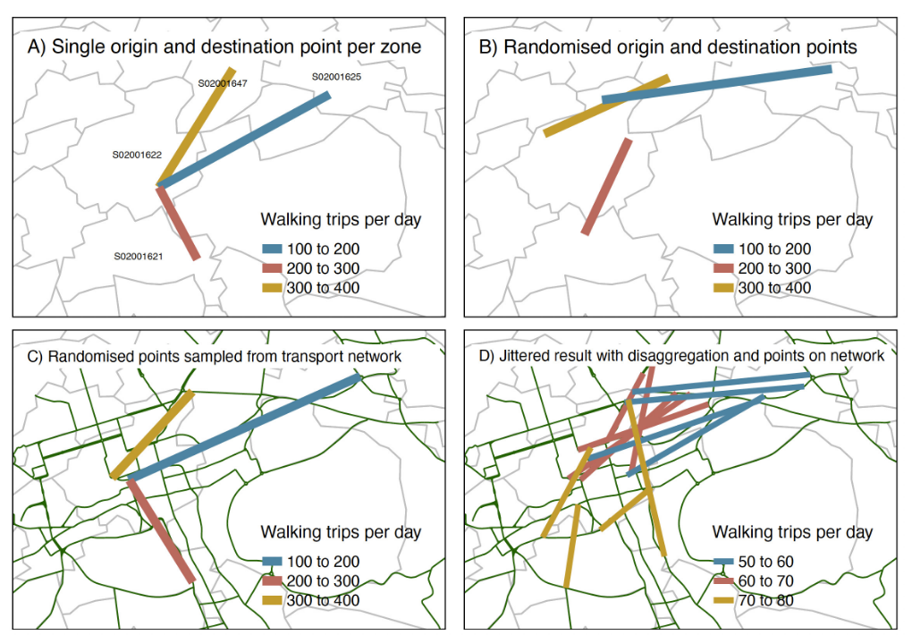

### TRACE: scalable, low-cost active travel counts

[figure not shown]

### SchoolRoutes: safer, greener routes to school

[figure not shown]

### NetGen: crowd-informed network generation; “the crowd is the territory” (Anderson et al. 2018)

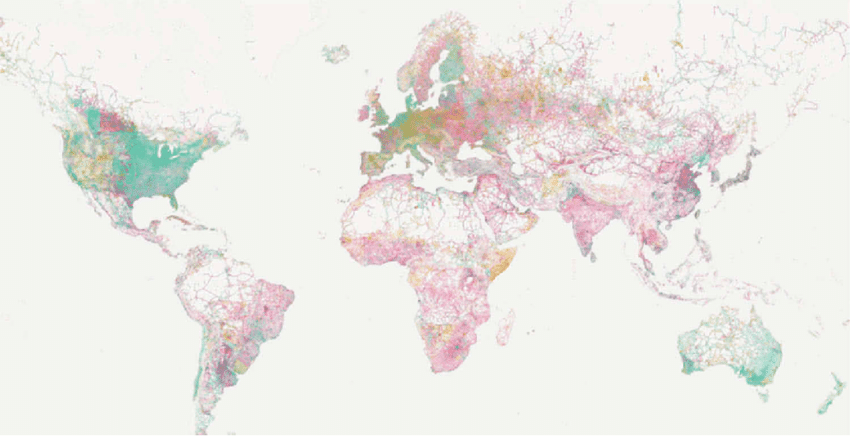

# Thank you

## References

Anderson, Jennings, Robert Soden, Brian Keegan, Leysia Palen, and Kenneth M. Anderson. 2018. “The Crowd Is the Territory: Assessing Quality in Peer-Produced Spatial Data During Disasters.” *International Journal of HumanComputer Interaction* 34 (4): 295–310. https://doi.org/10.1080/10447318.2018.1427828.

Lovelace, Robin, Rosa Félix, and Dustin Carlino. 2022. “Jittering: A Computationally Efficient Method for Generating Realistic Route Networks from Origin-Destination Data.” *Findings*, April, 33873. https://doi.org/10.32866/001c.33873.

Lovelace, Robin, John Parkin, and Tom Cohen. 2020. “Open Access Transport Models: A Leverage Point in Sustainable Transport Planning.” *Transport Policy* 97 (October): 47–54. https://doi.org/10.1016/j.tranpol.2020.06.015.